# Linear Regression: Release Date

Mary Solomon

2/15/2021

set levels of ordinal data, and other variables to their appropriate dataypes. Did not adjust the datatypes for date/time since those will not be used in this portion

```r
data <- fread("kpopdata.csv")
data <- mutate(data, ArtistType = as.factor(ArtistType),
               ArtistGender = as.factor(ArtistGender),
               ArtistGen = factor(ArtistGen),
               release_date = as.POSIXct(release_date, format = "%m/%d/%y"),
               key = factor(key, levels = 0:11),
               mode = as.factor(mode),
               time_signature = factor(time_signature, levels = c(1,3,4,5)))

#make month/year as continuous data in the form of number of months (~360)
ref.year = 1992 #we are using January 1992 as the reference
data$months = 12*(year(data$release_date) - ref.year) + month(data$release_date)
#View(select(data, Artist, song_name, release_date, months))
```

check out distribution of the months

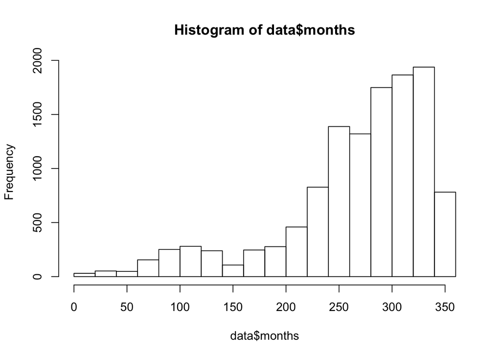

```r
hist(data$months)
```

```r
summary(data$months)
```

```
##    Min. 1st Qu.  Median    Mean 3rd Qu.    Max.
##     3.0   241.0   285.0   266.3   317.0   349.0
```

try to find a transformation to normalize

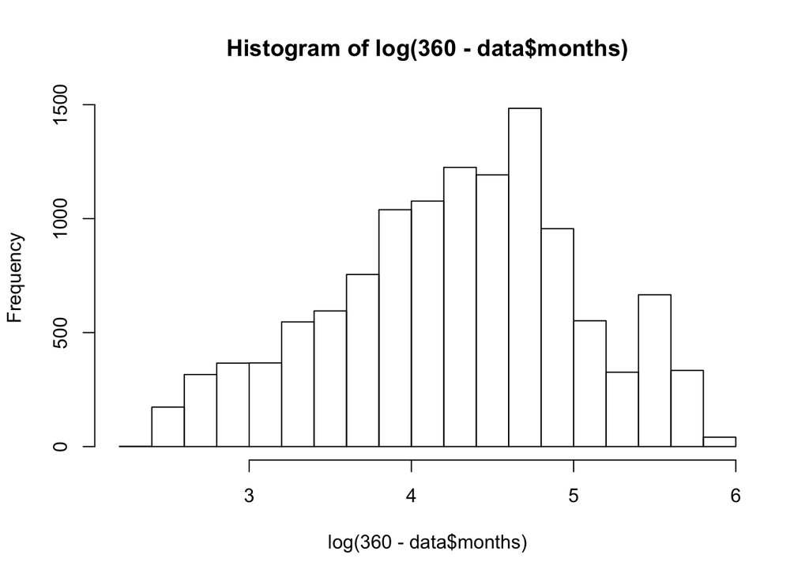

```r
hist(log(360-data$months))
```

# splitting into training and test data.

Create Training (75%) and Test data (25%) to train classification models on.

```r
kpop <- select(data, months, popularity, duration, acousticness, danceability, energy, instrumentalness, key, loudness, mode, speechiness, tempo, valence)
kpop0 <- kpop %>% filter(mode == 0)%>% select(-mode)
kpop1 <- kpop %>% filter(mode == 1) %>% select(-mode)

### Kpop mode 0 train and test
smpl.size0 <- floor(0.75*nrow(kpop0))
set.seed(123)
smpl0 <- sample(nrow(kpop0), smpl.size0, replace = FALSE)
train0 <- kpop0[smpl0,]
test0 <- kpop0[-smpl0,]

### Kpop mode 1 train and test
smpl.size1 <- floor(0.75*nrow(kpop1))
set.seed(123)
smpl1 <- sample(nrow(kpop1), smpl.size1, replace = FALSE)
train1 <- kpop1[smpl1,]
test1 <- kpop1[-smpl1,]
```

### Multiple linear regression for mode 0 songs

```r
ml0 <- lm(months ~. , data = train0)
summary(ml0)
```

```
##
## Call:
## lm(formula = months ~ ., data = train0)
##
## Residuals:
##      Min       1Q   Median       3Q      Max
## -220.905  -29.308    6.643   37.204  199.560
##
## Coefficients:
##                   Estimate Std. Error t value Pr(>|t|)
## (Intercept)      506.91441   16.88344  30.024  < 2e-16 ***
## popularity         1.60481    0.05435  29.528  < 2e-16 ***
## duration         -20.26179    1.81712 -11.151  < 2e-16 ***
## acousticness      31.41991    6.58842   4.769 1.93e-06 ***
## danceability     -61.87134   10.53878  -5.871 4.74e-09 ***
## energy           -98.67824   10.85541  -9.090  < 2e-16 ***
## instrumentalness  69.35253   14.06277   4.932 8.54e-07 ***
## key1              -3.38890    4.81002  -0.705 0.481137
## key2              -8.25574    5.95496  -1.386 0.165724
## key3              -4.68988    6.66026  -0.704 0.481381
## key4             -16.64198    4.72042  -3.526 0.000428 ***
## key5              -6.37892    4.57708  -1.394 0.163508
## key6              -7.69000    4.77927  -1.609 0.107700
## key7              -3.91007    5.23715  -0.747 0.455354
## key8              -1.77216    5.65747  -0.313 0.754115
## key9             -16.31280    4.85082  -3.363 0.000780 ***
## key10            -13.05634    4.99295  -2.615 0.008962 **
## key11            -13.43026    4.45880  -3.012 0.002613 **
## loudness          14.12750    0.67833  20.827  < 2e-16 ***
## speechiness       39.57966   15.28264   2.590 0.009642 **
## tempo             -0.12300    0.04024  -3.057 0.002255 **
## valence          -25.15503    5.77332  -4.357 1.36e-05 ***
## ---
## Signif. codes:  0 '***' 0.001 '**' 0.01 '*' 0.05 '.' 0.1 ' ' 1
##
## Residual standard error: 55.61 on 3482 degrees of freedom
## Multiple R-squared:  0.4143, Adjusted R-squared:  0.4108
## F-statistic: 117.3 on 21 and 3482 DF,  p-value: < 2.2e-16
```

check assumptions with diagnostic plots

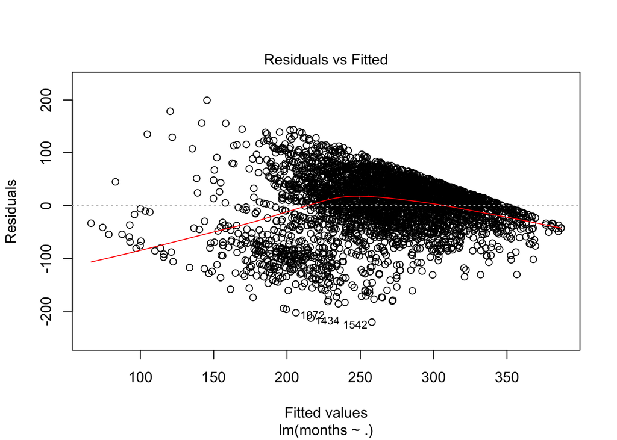

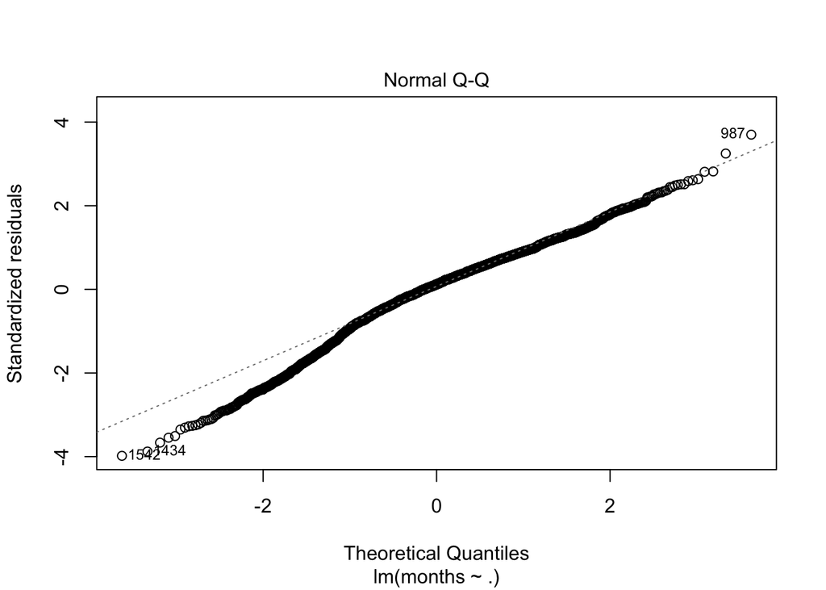

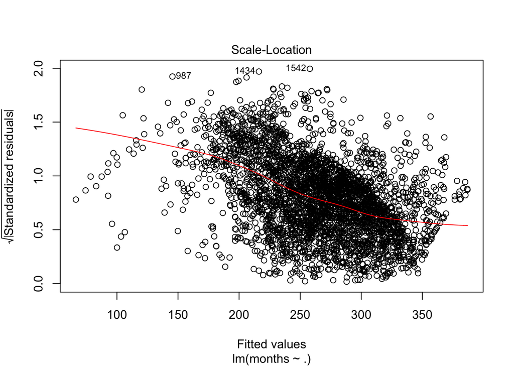

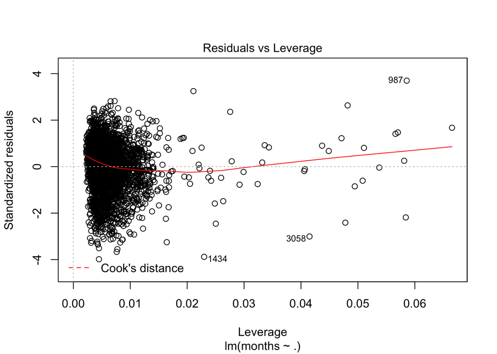

```r
#par(mfrow = c(4,1))
plot(ml0)
```

- Residuals vs. Fitted : Does not show a horizontal line. There is a noticeable pattern of a slight curve in the trend.
- Normal QQ: Residual points roughly follow the normal QQ line. The left side falls below the normal line below theoretical quantile -2. Otherwise, the distribution of the residuals appears to roughly follow a normal distribution.

*Scale-Location: Due to the clear decreasing line rather thana flat horizontal line of equally spread points, there is clear evidence of violation for homogeneity of the variance of the residuals. May need to run the model on a transformation of the outcome variable which is the months of song release.

- Residuals vs Leverage: There are some points that exceed -3 and 3 standard deviations, so we sould remove such points.

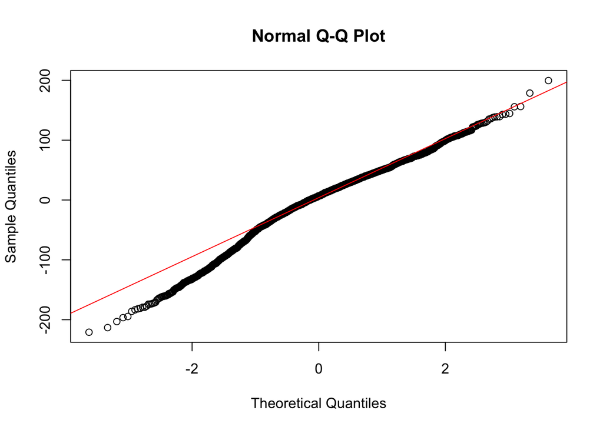

```r
qqnorm(ml0$residuals)
qqline(ml0$residuals, col = "red")
```

checking for multicollinearity

```r
car::vif(ml0)
```

```
##                      GVIF Df GVIF^(1/(2*Df))
## popularity       1.166795  1        1.080183
## duration         1.095607  1        1.046713
## acousticness     1.572984  1        1.254187
## danceability     1.463926  1        1.209928
## energy           2.625882  1        1.620457
## instrumentalness 1.062607  1        1.030828
## key              1.085836 11        1.003750
## loudness         1.974944  1        1.405327
## speechiness      1.078396  1        1.038458
## tempo            1.112227  1        1.054622
## valence          1.540583  1        1.241202
```

### Multiple linear regression for mode 1 songs